# Taller PCA 1 y 2

Juan Pablo Mosquera Marin - 20221020026 Ana Laura Morcote Chacon - 20221020010 Hana Sofia Pinilla Manrique - 20221020092 Juan David Amaya Patiño - 20221020057

2026-10-17

# Parte 1 - PCA 1

## 1. El encargo (0,5)

En un párrafo: **quién es su cliente, qué decisión toma y con qué variables numéricas la toma hoy**. Escojan entre 4 y 10 variables numéricas de su base, y digan por qué esas.

## 2. ¿Se repiten? (0,8)

Hagan la matriz de correlaciones de esas variables, en gráfico. Respondan:

- ¿Qué variables se repiten más?
- ¿Cuál va más sola?
- ¿Tiene sentido resumirlas? Si casi todas las correlaciones están cerca de cero, **díganlo**: ésa también es una respuesta para el cliente.

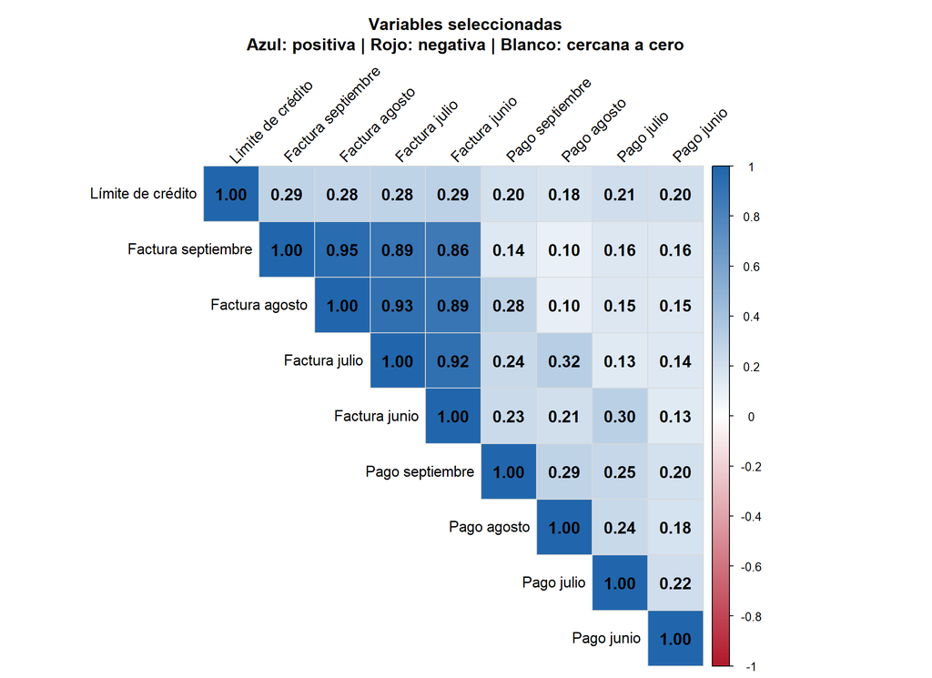

**Correlación entre variables**

Las facturas son las variables que más se repiten entre sí. Las correlaciones más altas aparecen entre meses consecutivos (septiembre-agosto, agosto-julio y julio-junio): un cliente con una factura alta en un mes tiende a tener también una factura alta al mes siguiente. Esto sugiere un uso sostenido de la tarjeta, con gastos recurrentes de un mes a otro.

Los pagos, en cambio, muestran correlaciones débiles entre sí. El monto que un cliente paga en un mes dice poco sobre lo que pagará en el siguiente, lo que indica un comportamiento de pago irregular: cada persona paga según su capacidad y decisión en cada momento, sin un patrón estable entre meses cercanos.

Por último, el límite de crédito casi no se relaciona con las facturas ni con los pagos. Esto sugiere que el cupo se asigna con base en otros factores del historial crediticio del cliente, que no se observan en estos cuatro meses.

**Variable mas sola**

La variable que menos se correlaciona con las demás es el pago de junio (*PAY_AMT4*). Esto significa que lo que un cliente pagó en junio aporta poca información sobre sus otros pagos, sus facturas o su límite de crédito. Es, por tanto, la variable más independiente del conjunto.

**Sentido de resumirlas**

Resumir tiene sentido sobre todo para las facturas. Como están muy correlacionadas entre sí (un cliente con factura alta en un mes suele tenerla también en los meses cercanos), una sola componente puede representar buena parte de lo que las cuatro dicen por separado.

En cambio, los pagos y el límite de crédito tienen correlaciones bajas entre ellos y con las facturas. Cada uno aporta información distinta, ligada a cómo cada cliente usa su tarjeta, y al combinarlos en pocas componentes se perdería parte de esa información.

Además, que un resumen conserve mucha variación no garantiza que sirva para decidir. Para el banco, su utilidad debe comprobarse frente a lo que realmente le importa: identificar a los clientes que no pagarán el mes siguiente.

## 3. ¿Estandarizar? (0,7)

Muestren la desviación de cada variable. **Decidan antes de correr** si estandarizan y justifíquenlo. Después corran el PCA **de las dos maneras** y muestren cuánto cambia la información que guarda la primera componente.

NTD: nuevos dólares taiwaneses. Amplitud = máximo − mínimo.

| Variable / mes | Mínimo | Máximo | Amplitud | Media | Mediana | Desviación estándar |
| --- | --- | --- | --- | --- | --- | --- |
| **LÍMITE DE CRÉDITO · Cupo otorgado** |  |  |  |  |  |  |
| LIMIT_BAL · Límite de crédito | 10.000 | 1.000.000 | 990.000 | 167.484,32 | 140.000,0 | 129.747,66 |
| **FACTURACIÓN · Montos de los estados de cuenta** |  |  |  |  |  |  |
| BILL_AMT1 · Septiembre | -165.580 | 964.511 | 1.130.091 | 51.223,33 | 22.381,5 | 73.635,86 |
| BILL_AMT2 · Agosto | -69.777 | 983.931 | 1.053.708 | 49.179,08 | 21.200,0 | 71.173,77 |
| BILL_AMT3 · Julio | -157.264 | 1.664.089 | 1.821.353 | 47.013,15 | 20.088,5 | 69.349,39 |
| BILL_AMT4 · Junio | -170.000 | 891.586 | 1.061.586 | 43.262,95 | 19.052,0 | 64.332,86 |
| **PAGOS · Montos efectivamente pagados** |  |  |  |  |  |  |
| PAY_AMT1 · Septiembre | 0 | 873.552 | 873.552 | 5.663,58 | 2.100,0 | 16.563,28 |
| PAY_AMT2 · Agosto | 0 | 1.684.259 | 1.684.259 | 5.921,16 | 2.009,0 | 23.040,87 |
| PAY_AMT3 · Julio | 0 | 896.040 | 896.040 | 5.225,68 | 1.800,0 | 17.606,96 |
| PAY_AMT4 · Junio | 0 | 621.000 | 621.000 | 4.826,08 | 1.500,0 | 15.666,16 |

Nota: NT$: nuevos dólares taiwaneses. Amplitud = máximo − mínimo. Desviación estándar: dispersión de los valores alrededor de la media. Aunque todas las variables comparten unidad monetaria, sus magnitudes y dispersiones son diferentes.

**Aclaraciones y por qué se estandariza**

En todas las variables, la media es mayor que la mediana. Esto indica que la distribución tiene una cola hacia valores altos: unos pocos clientes con facturas o pagos muy grandes elevan el promedio, mientras que la mayoría se ubica por debajo de él. Por eso la media, por sí sola, no describe al cliente típico. Por ejemplo, en septiembre la factura promedio es de 51.223 NTD, pero la mediana es de 22.382 NTD, es decir, menos de la mitad.

La dispersión también es alta en todas las variables. En las facturas hay valores negativos y valores muy altos, con amplitudes superiores a 1.000.000 NTD. En los pagos, muchos clientes pagan cero, mientras que unos pocos pagan montos enormes (hasta 1.684.259 NTD en agosto). Como resultado, la desviación estándar de los pagos es entre tres y cuatro veces mayor que su media. El límite de crédito, por su parte, varía entre 10.000 y 1.000.000 NTD.

Aunque todas las variables están en la misma unidad monetaria, sus escalas son muy diferentes: la desviación estándar va desde unos 15.700 NTD en los pagos hasta unos 129.700 NTD en el límite de crédito. Sin estandarizar, las variables con mayor dispersión dominarían el PCA solo por su escala. Por eso se decide estandarizar.

**Estandarización**

La estandarización se aplicó a las nueve variables numéricas seleccionadas: el límite de crédito, los cuatro montos facturados y los cuatro montos pagados. A cada observación se le restó la media de su variable y el resultado se dividió entre su desviación estándar, mediante `scale(center = TRUE, scale = TRUE)`. Así, cada variable quedó con media cero y desviación estándar uno, sin unidades. Esto permite compararlas en una escala común y evita que las de mayor dispersión dominen el PCA. Las variables originales se conservaron en un objeto aparte.

**PCA**

PCA sin estandarizar

| PC | Varianza (%) Indiv. | Varianza (%) Acum. | Límite Cupo | Facturas · Contribución (%) Sep. | Facturas · Contribución (%) Ago. | Facturas · Contribución (%) Jul. | Facturas · Contribución (%) Jun. | Pagos · Contribución (%) Sep. | Pagos · Contribución (%) Ago. | Pagos · Contribución (%) Jul. | Pagos · Contribución (%) Jun. |
| --- | --- | --- | --- | --- | --- | --- | --- | --- | --- | --- | --- |
| PC1 | 60,45 | 60,45 | 43,69 | 15,56 | 14,78 | 13,90 | 11,71 | 0,09 | 0,12 | 0,08 | 0,05 |
| PC2 | 32,66 | 93,11 | 56,10 | 12,18 | 12,21 | 11,00 | 8,50 | 0,00 | 0,00 | 0,00 | 0,01 |
| PC3 | 2,53 | 95,64 | 0,06 | 26,70 | 6,86 | 15,12 | 18,67 | 2,25 | 27,49 | 2,76 | 0,09 |
| PC4 | 1,37 | 97,01 | 0,00 | 2,26 | 0,42 | 12,47 | 44,54 | 0,67 | 29,02 | 9,77 | 0,85 |
| PC5 | 1,03 | 98,04 | 0,14 | 9,67 | 0,11 | 13,78 | 0,36 | 8,46 | 11,40 | 40,78 | 15,30 |
| PC6 | 0,91 | 98,96 | 0,00 | 19,52 | 29,76 | 0,01 | 1,54 | 43,18 | 5,29 | 0,24 | 0,47 |
| PC7 | 0,53 | 99,49 | 0,00 | 0,87 | 0,89 | 2,06 | 0,42 | 2,67 | 5,50 | 4,83 | 82,77 |
| PC8 | 0,30 | 99,79 | 0,00 | 8,84 | 9,15 | 9,16 | 10,61 | 26,10 | 1,86 | 34,26 | 0,01 |
| PC9 | 0,21 | 100,00 | 0,00 | 4,41 | 25,82 | 22,50 | 3,66 | 16,58 | 19,31 | 7,27 | 0,45 |

PCA estandarizado

| PC | Varianza (%) Indiv. | Varianza (%) Acum. | Límite Cupo | Facturas · Contribución (%) Sep. | Facturas · Contribución (%) Ago. | Facturas · Contribución (%) Jul. | Facturas · Contribución (%) Jun. | Pagos · Contribución (%) Sep. | Pagos · Contribución (%) Ago. | Pagos · Contribución (%) Jul. | Pagos · Contribución (%) Jun. |
| --- | --- | --- | --- | --- | --- | --- | --- | --- | --- | --- | --- |
| PC1 | 45,66 | 45,66 | 4,39 | 20,45 | 21,66 | 21,95 | 21,43 | 3,35 | 2,47 | 2,57 | 1,74 |
| PC2 | 16,89 | 62,56 | 7,30 | 5,73 | 4,44 | 2,33 | 1,63 | 18,60 | 21,22 | 21,43 | 17,33 |
| PC3 | 9,81 | 72,36 | 22,08 | 0,77 | 0,01 | 1,57 | 0,24 | 11,35 | 28,51 | 0,10 | 35,35 |
| PC4 | 8,71 | 81,07 | 24,28 | 0,08 | 0,41 | 0,90 | 0,61 | 3,29 | 1,54 | 27,86 | 41,04 |
| PC5 | 8,58 | 89,66 | 41,19 | 0,31 | 0,21 | 0,55 | 1,46 | 0,20 | 10,19 | 43,81 | 2,09 |
| PC6 | 8,13 | 97,79 | 0,71 | 0,14 | 1,35 | 1,09 | 0,29 | 61,73 | 31,42 | 1,25 | 2,01 |
| PC7 | 1,49 | 99,27 | 0,02 | 36,59 | 7,33 | 5,13 | 47,76 | 0,01 | 1,79 | 0,92 | 0,43 |
| PC8 | 0,46 | 99,73 | 0,02 | 23,11 | 11,90 | 37,66 | 23,88 | 0,61 | 0,96 | 1,85 | 0,00 |
| PC9 | 0,27 | 100,00 | 0,00 | 12,82 | 52,68 | 28,82 | 2,71 | 0,86 | 1,88 | 0,22 | 0,01 |

**Cómo leer las tablas:** Indiv. = varianza explicada por cada componente; Acum. = varianza acumulada. Azul: límite de crédito; naranja: facturas; verde: pagos. Las contribuciones se calculan como 100 × peso² y suman 100% entre las nueve variables de cada fila. No representan la varianza de cada variable explicada por la componente.

## 4. Cuánta información guarda (1,0)

Con su decisión del punto 3:

1. La gráfica de cuánta información guarda cada componente, con el acumulado.

2. ¿Cuánta guarda la primera? ¿Cuántas hacen falta para pasar de 80 de cada 100?

| Análisis | Varianza explicada por la primera componente | Componentes necesarias para superar el 80 % | Varianza acumulada con esas componentes |
| --- | --- | --- | --- |
| Sin estandarizar | 60,45 % | 2 | 93,11 % |
| Estandarizado | 45,66 % | 4 | 81,07 % |

Para el análisis, tomaremos el PCA estandarizado, porque permite considerar las nueve variables sin que su dispersión determine su influencia de un grado tan dispar. En este caso, tres componentes conservan 72,36 %, por lo que necesitamos una cuarta para superar el umbral.

3. Escriban, en una frase para el cliente, qué significa esa cifra.

“Las nueve variables financieras de sus clientes se pueden resumir en cuatro índices que conservan el 81 % de la información; esto simplifica el seguimiento, pero queda por comprobar si ese resumen sirve para identificar a quienes no pagarán el mes siguiente.”

## 5. Qué mide cada una (1,0)

Grafiquen los pesos de las dos o tres primeras componentes. **Pónganle nombre a cada una** mirando qué variables mandan, y expliquen el nombre. Recuerden que el signo es arbitrario: se lee qué manda y si las variables van en la misma dirección o en contra.

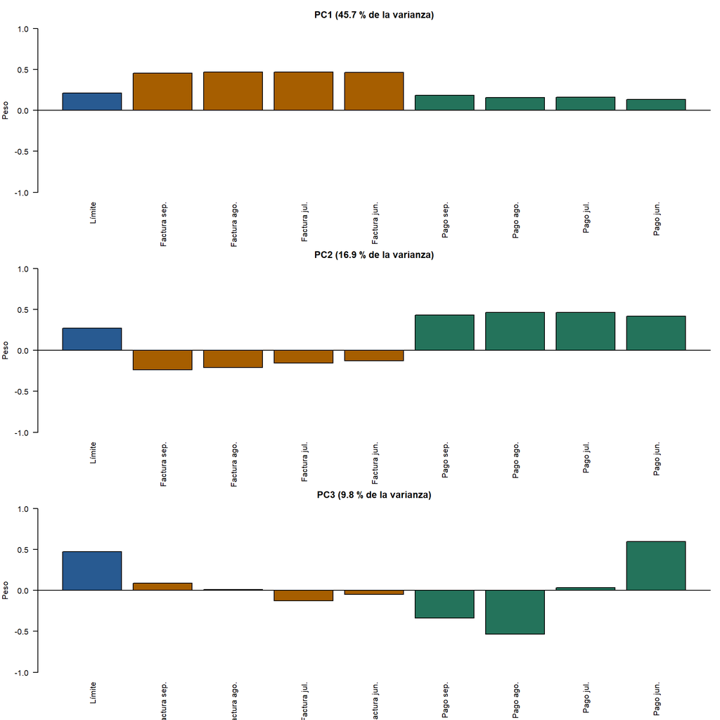

```
##                PC1    PC2    PC3
## Límite       0.210  0.270  0.470
## Factura sep. 0.452 -0.239  0.088
## Factura ago. 0.465 -0.211  0.011
## Factura jul. 0.469 -0.153 -0.125
## Factura jun. 0.463 -0.128 -0.049
## Pago sep.    0.183  0.431 -0.337
## Pago ago.    0.157  0.461 -0.534
## Pago jul.    0.160  0.463  0.032
## Pago jun.    0.132  0.416  0.595
```

Con esa gráfica, la lectura de cada componente se hace así:

1. PC1 (45,7 % de la varianza): “deuda acumulada”

Las cuatro facturas mandan con pesos casi iguales 0,46 a 0,47 y todas con el mismo signo. El límite 0,2 y los cuatro pagos 0,13 a 0,18 aportan poco, aunque también en positivo. Por eso esta componente mide qué tan alta es la facturación del cliente de forma sostenida en los cuatro meses. Un valor alto indica un cliente con facturas grandes de forma persistente. Como todos los pesos son positivos, ninguna variable va en contra de las demás: es una componente de tamaño general, y el signo es arbitrario.

2. PC2 (16,9 %): “Pagos frente a facturas”

Los cuatro pagos mandan con signo positivo 0,42 a 0,47. Las cuatro facturas tienen signo negativo, aunque con menos peso −0,13 a −0,25. El límite aporta algo positivo 0,27. Aquí los pagos van en contra de las facturas: un valor alto describe a quien paga mucho con facturas relativamente bajas, y un valor bajo, a quien paga poco frente a lo que le facturan. Es la dimensión que separa el esfuerzo de pago de la deuda, y por eso es la más relevante para la intervención temprana.

Esta es la más difícil de nombrar, porque mezcla varias cosas. Mandan el pago de junio 0,6, el límite +0,47, el pago de agosto −0,53 y el pago de septiembre −0,34. Las facturas y el pago de julio casi no pesan. Se lee como un contraste temporal en los pagos un valor alto describe a un cliente que pagó más en junio y menos en agosto y septiembre, con un cupo alto. Es decir, un cambio en el patrón de pagos entre el inicio y el final del periodo. se podria nombrar como Cambio en el patrón de pagos y aclarar que es una interpretación tentativa, porque explica solo 9,8 % y su lectura es menos nítida.

## 6. El costo para su cliente (1,0)

Ésta es la pregunta de la clase aplicada a su negocio: **si su cliente decidiera con un solo número, ¿a quién o a qué dejaría por fuera?**

- Definan un grupo que al cliente le importe: los peores, los mejores, los de riesgo, los que cumplen una condición.
- Cuenten cuántos de ese grupo encuentra la primera componente, y **cuántos se le escapan**.
- Cierren con la decisión: ¿le basta un número, o necesita reportar dos o tres?

```r
# AJUSTAR: nombre exacto de la columna en datos_credit
col_default <- "default payment next month"

# Mismas filas que usó el PCA
filas_ok <- complete.cases(datos_credit[, variables_seleccionadas])
y <- datos_credit[[col_default]][filas_ok]

puntajes <- pca_estandarizado$x
tasa <- mean(y == 1)
n_incumplen <- sum(y == 1)

evaluar <- function(marca, nombre) {
  encontrados <- sum(marca & y == 1)
  data.frame(
    Regla = nombre,
    Marcados = sum(marca),
    Encontrados = encontrados,
    `Se escapan` = n_incumplen - encontrados,
    `% encontrado` = round(100 * encontrados / n_incumplen, 1),
    `% acierto entre marcados` = round(100 * encontrados / sum(marca), 1),
    Lift = round((encontrados / sum(marca)) / tasa, 2),
    check.names = FALSE
  )
}

marca_pc1 <- puntajes[, 1] >= quantile(puntajes[, 1], 1 - tasa)
marca_pc2 <- puntajes[, 2] <= quantile(puntajes[, 2], tasa)

resultado <- rbind(
  evaluar(marca_pc1, "PC1 alta (mucha facturación)"),
  evaluar(marca_pc2, "PC2 baja (paga poco frente a lo facturado)"),
  evaluar(marca_pc1 | marca_pc2, "PC1 o PC2")
)

cat("Tasa de incumplimiento:", round(100 * tasa, 1), "%  |  Incumplidos:", n_incumplen, "\n")
```

```
## Tasa de incumplimiento: 22.1 %  |  Incumplidos: 6636
```

```r
resultado
```

| Regla | Marcados | Encontrados | Se escapan | % encontrado | % acierto entre marcados | Lift |
| --- | --- | --- | --- | --- | --- | --- |
| PC1 alta (mucha facturación) | 6636 | 1224 | 5412 | 18.4 | 18.4 | 0.83 |
| PC2 baja (paga poco frente a lo facturado) | 6636 | 1651 | 4985 | 24.9 | 24.9 | 1.12 |
| PC1 o PC2 | 8907 | 1876 | 4760 | 28.3 | 21.1 | 0.95 |

Para el banco, el grupo que importa son los clientes que no pagarán el mes siguiente default payment next month = 1: 6.636 clientes, el 22,1 % de la base. Para comparar de forma justa, cada regla marca al 22,1 % de clientes con valores más extremos en la componente (6.636 clientes).

**Qué encuentra la primera componente.** Si el banco decidiera con un solo número, la PC1 nivel de facturación, y marcara a los clientes con facturación más alta, encontraría 1.224 incumplidos y se le escaparían 5.412: el 81,6 % de quienes no pagan quedaría por fuera. De cada 100 clientes marcados, solo 18,4 incumplen, frente a 22,1 de cada 100 al escoger al azar, esta regla es peor que el azar. Tiene sentido, porque la PC1 mide cuánto se factura, y tener una factura alta no implica dejar de pagar.

**Qué cambia con la segunda componente.** Marcar a quienes tienen la PC2 baja pagan poco frente a lo facturada encuentra 1.651 incumplidos y deja escapar 4.985 75,1 %. El acierto sube a 24,9 %. Es mejor que el azar, pero la mejora es tres de cada cuatro incumplidos siguen sin ser detectados.

**Combinar ambas.** Marcar a los clientes que cumplan la regla de la PC1 o la de la PC2 señala a 8.907 clientes y encuentra 1.876 incumplidos (28,3 %), con 4.760 que se escapan. Frente a usar solo la PC2, se marcan 2.271 clientes más para encontrar apenas 225 incumplidos adicionales. Es decir, agregar la PC1 vuelve la regla menos eficiente.

**Decisión.** A este cliente no le basta un número, y tampoco le bastan dos: reportar PC1 y PC2 no mejora de forma útil la detección. Si hubiera que quedarse con una sola, sería la PC2 pagos frente a facturas, que es la única que supera al azar, aunque por poco. La razón de fondo es que estas componentes resumen cuánto se factura y cuánto se paga, y eso no captura si el cliente se está atrasando. Para intervenir de forma temprana, el banco necesitaría incluir las variables de historial de atraso PAY_0 a PAY_6, que quedaron fuera. Que el resumen conserve el 81 % de la variación no significa que conserve lo que sirve para decidir.

# Parte 2 - PCA 2

## 1. El mapa y sus direcciones (1,0)

Con las variables numéricas del taller anterior (y la misma decisión sobre estandarizar):

1. Dibujen sus casos en el plano de las dos primeras componentes. ¿Cuánta información guarda?

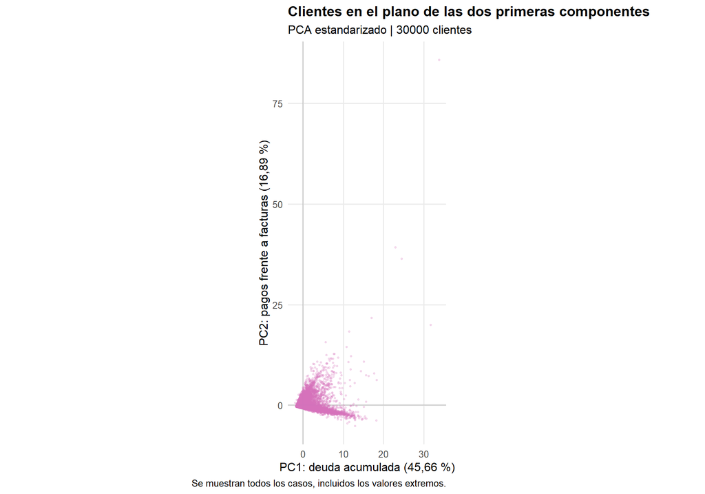

**Información conservada:** El plano guarda el **62,56 %** de la variación de las nueve variables. Queda fuera el 37,44 %, por lo que el mapa es un resumen parcial del perfil financiero.

2. **Pónganle nombre a cada dirección**: qué significa ir a la derecha y qué significa ir hacia arriba, para su cliente.

**Rta:** Ir a la **derecha** indica mayor facturación sostenida. Ir a la **izquierda** indica facturación baja, que incluye tanto a clientes con poca deuda como a quienes tienen saldo a favor (facturas negativas), ya que la PC1 no distingue entre ambos casos. Ir hacia **arriba** indica mayores pagos en contraste con las facturas; no representa una razón pago/factura ni una probabilidad de incumplimiento.

3. Fijen el signo de cada componente para que se lea fácil, y digan cómo lo fijaron.

**Rta:** Se orientó PC1 para que la suma de los pesos de las cuatro facturas fuera positiva y PC2 para que la suma de los pesos de los cuatro pagos fuera positiva. El mismo cambio se aplicó a los puntajes y a los pesos; esto no modifica la varianza explicada.

## 2. El biplot (1,0)

*Responsable: Ana👻👻👻*

Hagan el biplot: los casos como puntos y las variables como flechas.

- ¿Qué flechas van juntas? Digan el ángulo aproximado entre ellas.
- ¿Cuál va sola? ¿Alguna va en contra de otra?
- Si hay muchas etiquetas encima, arréglenlas: un biplot que no se lee no cuenta.

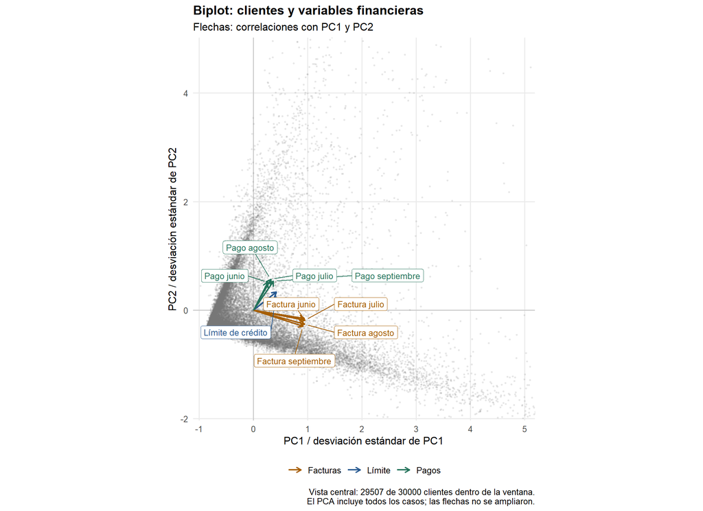

**Flechas que van juntas:** Las cuatro facturas apuntan hacia la derecha y ligeramente hacia abajo, con ángulos aproximados entre 2,0° y 8,3°. Esto respalda la interpretación de PC1 como “deuda acumulada” definida en PCA 1. Los cuatro pagos apuntan hacia arriba y a la derecha, con ángulos entre 0,3° y 7,4°: presentan una dirección semejante en este plano.

**Flecha más independiente:** Ninguna aparece flecha claramente aislada. El límite de crédito queda entre ambos conjuntos, más cerca de los pagos, con los que forma ángulos de aproximadamente 17° a 24,4°

**Direcciones opuestas:** Facturas y pagos tienen signos contrarios en PC2, lo que respalda el nombre “pagos frente a facturas”. Sin embargo, ninguna pareja de flechas forma un ángulo mayor de 90° (lo cual NO significa que exista una correlación negativa entre sus variables originales)

**Alcance:** Los ángulos describen la proyección en dos componentes. En particular, la cercanía entre pagos no implica que sus correlaciones originales sean altas (parte de sus diferencias queda en las componentes omitidas, como ya mostró PCA 1)

## 3. ¿Hay grupos o hay un continuo? (1,0)

Miren la nube. **¿Tiene islas separadas por huecos, como setosa, o es una sola mancha?** Muéstrenlo con el gráfico y con una cifra: por ejemplo, dónde termina un grupo y dónde empieza el otro en la primera componente.

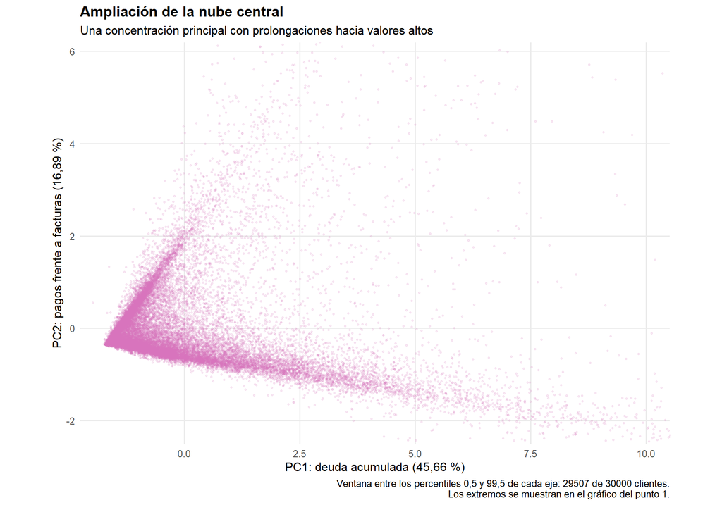

Extensión de los grupos observados sobre PC1 y PC2

| Grupo | Clientes | Mínimo de PC1 | Máximo de PC1 | Mínimo de PC2 | Máximo de PC2 |
| --- | --- | --- | --- | --- | --- |
| Cumplen | 23364 | -1,723 | 33,803 | -3,788 | 85,788 |
| Incumplen | 6636 | -1,978 | 17,648 | -5,228 | 10,845 |

**Forma de la nube:** La nube presenta una zona de alta concentración con dos prolongaciones conectadas, sin islas claramente separadas por huecos. Esto sugiere un continuo de perfiles financieros, más que grupos claramente diferenciados. Para el banco, el gráfico por sí solo no permite distinguir a quienes cumplen de quienes incumplen. Los extremos de la tabla corresponden a toda la base, mientras que el gráfico muestra una ampliación central.

**Evidencia numérica:** Los rangos de quienes cumplen y quienes incumplen se superponen en ambas componentes. Por tanto, ni “deuda acumulada” ni “pagos frente a facturas”, consideradas por separado, permiten separar completamente los dos grupos mediante un único corte. La tabla incluye todos los clientes, mientras que el gráfico muestra una ampliación de la zona central; por eso sus extremos no coinciden con los límites visibles.

**Conclusión para el banco.** El mapa no muestra tipos de clientes claramente separados ni permite identificar el incumplimiento mediante una frontera evidente. El solapamiento en PC1 complementa la inspección del plano; por sí solo no demuestra ausencia de grupos en otras dimensiones. El gráfico y los rangos no proporcionan evidencia suficiente para distinguir claramente a quienes cumplen de quienes incumplen; para evaluar su separación en el plano, es necesario observar el mapa coloreado por grupo.

## 4. ¿Los grupos que su cliente conoce se separan? (1,0)

Coloreen el mapa por **una variable de grupo** que su cliente use para decidir (tipo de cliente, región, categoría, lo que tengan). Dibujen las elipses del 90 %.

- ¿Se separan o solo se desplazan?
- Muéstrenlo con dos cifras: la distancia entre los promedios, y qué parte de un grupo cae en la zona del otro.
- Cierren con la frase para el cliente: ¿le sirve ese grupo para decidir, o no?

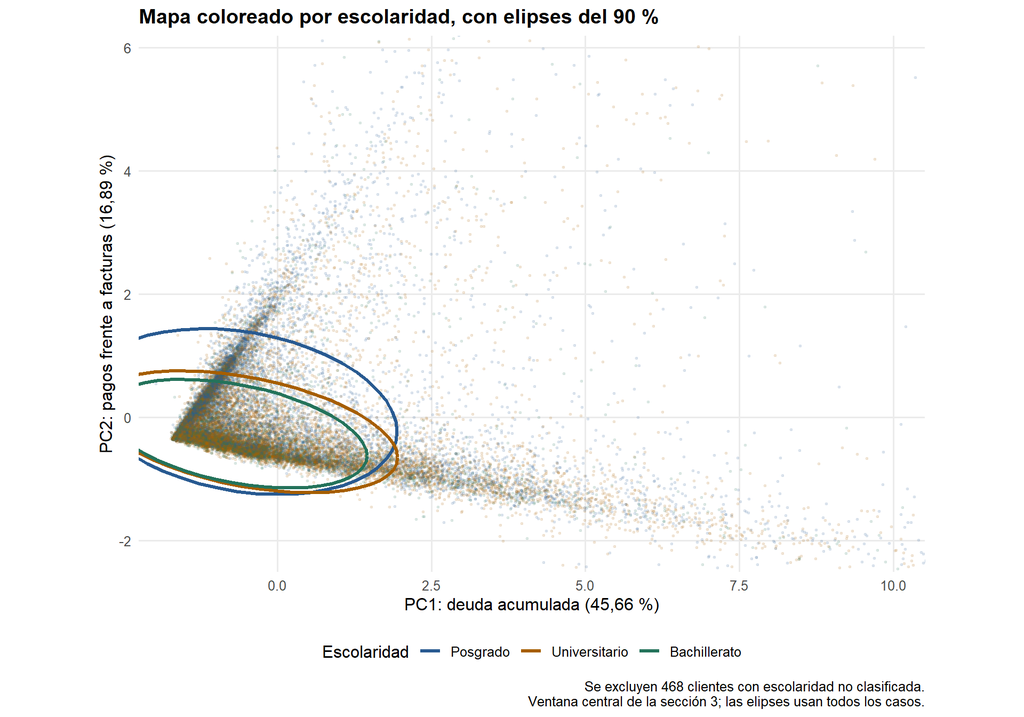

Separación entre grupos de escolaridad en el plano PC1-PC2

|  | Comparacion | Distancia entre promedios | Diferencia PC1 (en desv. est.) | Diferencia PC2 (en desv. est.) | % del 1.º dentro de la elipse del 2.º | % del 2.º dentro de la elipse del 1.º |
| --- | --- | --- | --- | --- | --- | --- |
| PC1 | Posgrado vs Universitario | 0,36 | 0,04 | 0,27 | 88,07 | 94,73 |
| PC11 | Posgrado vs Bachillerato | 0,46 | 0,14 | 0,28 | 86,80 | 96,12 |
| PC12 | Universitario vs Bachillerato | 0,20 | 0,11 | 0,02 | 90,53 | 93,29 |

Tamaño y promedio de cada grupo de escolaridad

| Grupo | Clientes | Promedio PC1 | Promedio PC2 |
| --- | --- | --- | --- |
| Posgrado | 10585 | 0,077 | 0,230 |
| Universitario | 14030 | -0,004 | -0,124 |
| Bachillerato | 4917 | -0,203 | -0,139 |

- Grupo usado: Se coloreó el mapa por nivel de escolaridad, una característica que el banco conoce de antemano y que no interviene en el cálculo del PCA. Se excluyeron 468 clientes con escolaridad no clasificada, por lo que el análisis usa 29.532 clientes: 10.585 de Posgrado, 14.030 de Universitario y 4.917 de Bachillerato.
- ¿Se separan o solo se desplazan?: Solo se desplazan. Las elipses del 90 % se superponen casi por completo y comparten la misma zona de mayor concentración. Los centros de los grupos están muy cerca: la distancia entre promedios es de 0,36 Posgrado vs. Universitario, 0,46 Posgrado vs. Bachillerato y 0,20 Universitario vs. Bachillerato, en las unidades de los ejes. En la PC1 de deuda acumulada las diferencias son mínimas, entre 0,04 y 0,14 desviaciones estándar. En la PC2 pagos frente a facturas Posgrado queda algo más arriba promedio de 0,230, frente a −0,124 en Universitario y −0,139 en Bachillerato, pero la diferencia es de apenas 0,27 a 0,28 desviaciones estándar. Entre Universitario y Bachillerato casi no hay diferencia con 0,02 en la PC2
- Cuánto cae en la zona del otro: Si dos grupos fueran idénticos, cerca del 90 % de uno caería dentro de la elipse del 90 % del otro. Aquí el 88,1 % de Posgrado cae dentro de la elipse de Universitario, y el 94,7 % de Universitario dentro de la de Posgrado. Con Bachillerato, el 86,8 % de Posgrado cae en su elipse y el 96,1 % de Bachillerato en la de Posgrado. Entre Universitario y Bachillerato, los valores son 90,5 % y 93,3 %. Todos están cerca del 90 % esperado para grupos que se mezclan por completo. Que los porcentajes sean mayores en un sentido que en el otro se explica porque Posgrado es el grupo más disperso y su elipse es más grande, no porque los grupos estén más separados.
- Conclusión para el banco: La escolaridad no le sirve para decidir a partir de este mapa: clientes de los tres niveles ocupan prácticamente la misma zona del plano, y la única diferencia visible, que Posgrado tiende a pagar algo más frente a sus facturas, es pequeña frente a la variación que hay dentro de cada grupo. Conocer el nivel de escolaridad de un cliente no permite ubicarlo en una zona distinta del mapa, y por tanto no ayuda a diferenciar su perfil de deuda ni de pagos.

## 5. La decisión en el mapa (1,0)

Propongan **uno o dos cortes** en el mapa que le sirvan a su cliente para actuar, y **cuenten cuántos casos caen en cada zona**. Digan qué haría el cliente con cada zona, y qué pasa si mueve el corte.

Se proponen **dos cortes**: uno vertical en **PC1 = 0** y uno oblicuo, la recta **PC2 = 0,3 · PC1**, que se aplica solo a la derecha del corte vertical. Esto divide el mapa en tres zonas:

- **Izquierda (PC1 < 0):** facturación por debajo de la del cliente promedio. Incluye a quienes deben poco, a quienes casi no usan la tarjeta y a quienes tienen saldo a favor (facturas negativas).
- **Derecha, arriba de la recta:** facturación media o alta, con pagos iguales o mayores a lo que corresponde a esa facturación.
- **Derecha, debajo de la recta:** facturación media o alta, con pagos menores a lo que corresponde. Es la zona a vigilar.

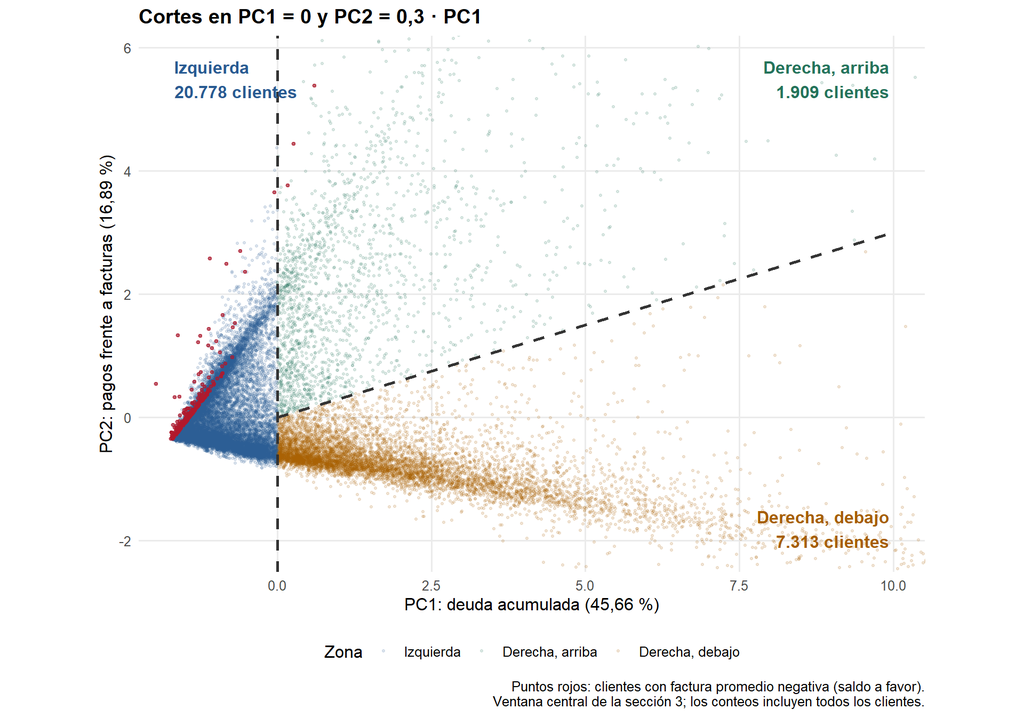

Perfil de cada zona del mapa

| Zona | Clientes | % de la base | Factura promedio (NTD) | % con factura promedio negativa | Pago total promedio (NTD) | Pago total mediano (NTD) |
| --- | --- | --- | --- | --- | --- | --- |
| Izquierda | 20.778 | 69,3 | 15.315,0 | 1,1 | 11.074,8 | 6.139 |
| Derecha, arriba | 1.909 | 6,4 | 68.257,1 | 0,2 | 129.731,1 | 104.002 |
| Derecha, debajo | 7.313 | 24,4 | 134.222,9 | 0,0 | 23.427,6 | 18.700 |

Clientes en la zona de vigilancia según la pendiente

| Pendiente | Clientes a vigilar | % de la base |
| --- | --- | --- |
| 0,0 | 7.003 | 23,3 |
| 0,1 | 7.177 | 23,9 |
| 0,3 | 7.313 | 24,4 |
| 0,5 | 7.464 | 24,9 |
| 1,0 | 7.794 | 26,0 |

**Cuántos caen en cada zona.** A la izquierda quedan 20.778 clientes (69.3 %), a la derecha y arriba de la recta 1.909 (6.4 %), y a la derecha y debajo 7.313 (24.4 %).

**Qué haría el cliente con cada zona.**

- **Izquierda:** no requiere intervención por deuda. Dentro de ella hay tres tipos de cliente (poca deuda, poco uso de la tarjeta y saldo a favor) que el mapa no distingue. El banco podría ofrecerles productos para aumentar el uso, y a quienes tienen saldo a favor, tratarlos como buenos pagadores. La tabla indica que 1,1 % de esta zona tiene saldo a favor.
- **Derecha, arriba de la recta:** clientes con deuda sostenida que pagan en proporción. Basta seguimiento normal y, a los de mayor pago, se les puede ofrecer más cupo.
- **Derecha, debajo de la recta:** es la zona a vigilar. Son clientes que deben mucho y pagan poco, por lo que el banco podría contactarlos de forma temprana o revisar su cupo.

**Qué pasa si se mueve el corte.** Mover el corte vertical a la derecha agranda la zona izquierda y deja sin vigilar a clientes con deuda moderada. Moverlo a la izquierda hace que la regla oblicua también aplique a clientes con facturación baja, que es justo lo que se quería evitar.

**Límite.** El corte en PC1 = 0 separa por facturación respecto al promedio, no por saldo a favor: la mayoría de los clientes de la izquierda tiene una factura positiva, solo menor al promedio. Los puntos rojos muestran que quienes tienen saldo a favor son una fracción pequeña de esa zona. Además, la recta compara puntajes de componentes y no equivale a una razón pago/factura. Los clientes cercanos a los cortes cambian de zona con ajustes pequeños, así que son reglas prácticas y no fronteras naturales entre tipos de cliente.